# Precio Equilibrio

## COSTOS, GASTOS Y PRECIO EQUILIBRIO

#### Referencias en última hoja.

> Buscamos el punto de equilibrio $(nV, P)$ tal que Egresos (nV) = Ingresos (nV); siendo $nV$ el numero de ventas y $P$ lo recaudado de ello (bruto)

### INGRESOS POR VENTA:

- Como nuestros precios no son siempre iguales (varian según tipo de guía), I(nV) depende de las ventas incluidas en ese "nV", entonces es la sumatoria del precio de las ventas que incluimos en nV.

$ I (nV) = \sum_{i}^{nV} ventas_{i}.precio $

- En nuestro caso, el precio de la guia es el costo base de venta $k$ (constante) más el costo diferencial (variable) con salarios $\mu$ (saldo de costo variable, incluyendo salarios) y una diferencia (también variable) para recaudar y pagar el costo fijo ($f(\mu) = coef*\sum_{i}^{nV}(k+\mu_{i})$). El precio depende del tipo de servicio que se haya elegido (según menu, tipo de entrada y- por lo tanto- comision $\psi\in\mu$ al respecto).

> Precio por venta $P(v)$:

> > $ P(v) = k + \psi_v + f(v)$

> Teniendo en cuenta que:

> > $k = REGALOS + MUSEO + FOTOS = BITACORA + REMERA + MUSEO + FOTOS$ $\mu = \sum_{j}^{nV} \psi_j + Menu_j + MuseoB_j $

> Tiene sentido decir:

> > $I (nV) = nV * k + \mu + coef*\sum_{i}^{nV}(k+\mu_{i}) = nV * k + \mu + coef*nV*k + coef*\sum_{i}^{nV}\mu_{i}$ $I (nV) = nV * k + \mu + f(\mu) $

### EGRESOS POR VENTA:

- En el caso de los egresos, estos se componen de un costo fijo $cf$ (el transporte independiente a la cantidad de ventas al lugar) y otro variable $\mu$ que incluye las diferencias en comision $\psi_j$, menu $M_j$ y tipo de entrada al museo $EMB_j$

> Egreso $E(v)$ por venta (sin costo fijo):

> > $E(v) = k + \psi_v + Menu_v + Museo_j = k + \mu_j$

> En síntesis:

> > **Costos fijos**: $cf = 2*4*(PrecioViaje) = 8 * 40 = 320$

> > **Costos variables**: $cv(nV) = nV * k + \sum_{j}^{nV} \psi_j + Menu_j + MuseoB_j $

## $E(nV) = cf + cv(nV) = cf + nV * k + \sum_{j}^{nV} \psi_j + Menu_j + MuseoB_j = cf + nV * k + \mu_j$

### PUNTO EQUILIBRIO:

- Con esto en mente, solo queda igualar $E(nV)$ con $I(nV)$ para obtener el $nV\in$ **Punto equilibrio**.

$I(nV) = E(nV)$

$nV * k + \mu + f = cf + nV * k + \mu_j$

$nV * k + \mu + coef*\sum_{j}^{nV}(k+\mu_{j}) = cf + nV * k + \mu_j$

$coef*\sum_{j}^{nV}(k+\mu_{j}) = cf$

$f(\mu) = cf$

- Como sabemos que $\mu$ es variable, para calcular el **punto de equilibrio** hay que volverlo constante. Como en cuestión de costos variables ya es solvente (se anularon), lo único variable son los ingresos en función a $\mu$. Decimos que si las ventas incluidas en ese $nV$ son las que tienen menos comision $f(\mu)$, es decir arg min (v) $f(\mu)$ pero igual saldan el $cf$ aún libre, entonces $nV$ es la cantidad mínima de productos a vender para igualar a los costos; porque cualquiera sea la elección de ventas diferente al argumento mínimo, siempre dará un retorno mayor.

$f = cf$

$coef*\sum_{j}^{nV}(k+\mu_{j}) = cf$

> Si $\mu$ es el menor valor posible:

> > $\forall \mu^{'} > \mu \rightarrow f(\mu^{'}) > f(\mu)$

> > $ \therefore si f(\mu) = cf \rightarrow f(\mu^{´}) >= cf$, cuando $\mu^{'} \in (\mu, MAX)$
- Lo que nos permite decir:

> $coef*nV*(k+u) = cf$

> $nV = \frac{cf}{coef*(k+\mu)}$ cuando arg min ($\mu$)

```python
CF = 320 + 5000

class CLIENTE:
    def __init__ (self, edad, nacionalidad):
        self.edad = edad
        self.nacionalidad = nacionalidad

class VENTA:
    # MUSEO BOQUENSE
    def __init__ (self, config, ID, cliente, menuComida, menuBebida):

        self.𝜓 = -1;
        self.config = config
        self.beneficio = -1;

        ADULTO_ARGENTINO = 1000
        ADULTO_EXTRANJERO = 2000
        MENOR_EXTRANJERO = 400
        MENOR_ARGENTINO = 200

        rr = 2500 # Precio remera
        br = 1200 # Precio bitácora con envio incluido
        𝜆 = rr + br # Suma de Regalos
        em = 200 # Entrada museo cera
        ft = 400 # Foto con Maradona + Libertadores
        self.costo_base = 𝜆 + em + ft # = K

        self.ID = ID
        self.menu_comida = menuComida
        self.menu_bebida = menuBebida

        if cliente.edad >= 18 and cliente.nacionalidad == "Argentina":
            self.emb = ADULTO_ARGENTINO
        elif cliente.edad >= 18 and cliente.nacionalidad != "Argentina":
            self.emb = ADULTO_EXTRANJERO
        if cliente.edad < 18 and cliente.nacionalidad == "Argentina":
            self.emb = MENOR_ARGENTINO
        elif cliente.edad < 18 and cliente.nacionalidad != "Argentina":
            self.emb = MENOR_EXTRANJERO

    def costo_diferencial (self):
        return self.emb + MENUS[self.menu_comida][self.menu_bebida]

    def costo_total (self):
        return self.costo_diferencial() + self.costo_base

    def precio (self, verb=False): # Precio por tipo de contrato

        𝜓Coef = config.𝜓Coef
        fCoef = config.fCoef

        self.𝜓 = 𝜓Coef * self.costo_total () # salarios
        self.beneficio = fCoef * self.costo_total ()

        if verb:
            print ("Costo diferencial: ", self.costo_diferencial(), " : emb: {} y menu: {}".format(self.emb, MENUS[self.menu_comida][self.menu_bebida]))
            print ("Costo base: ", self.costo_base)
            print ("Costo sin salarios: ", self.costo_total())
            print ("Salarios: ", self.𝜓)
            print (">>>> Presidente: {} || Vicepresidente: {} || Departamento A: {} || Departamento B:{}".format(self.𝜓*0.3046, 0.2608*self.𝜓, 0.2173*self.𝜓, 0.2173*self.𝜓))
            print ("Costo Total: ", self.costo_total() + self.𝜓)
            print ("Precio: ", self.costo_total() + self.𝜓 + self.beneficio)
            print ("Beneficio: ", self.beneficio)

        return self.costo_total() + self.𝜓 + self.beneficio
```

```python
import numpy as np
M = 10; N = 5
MENUS = np.zeros([M,N]) + 1520

def EGRESO (VENTAS):
    pp = .0
    for venta in VENTAS: pp += venta.costo_total()
    pp += CF
    return pp
```

```python
class METADATA:
    def __init__ (self, 𝜓Coef, fCoef):
        self.𝜓Coef = 𝜓Coef;
        self.fCoef = fCoef

config = METADATA(0.05, 0.28)
ClienteEjemplo = CLIENTE (10, "Argentina")
VentaEjemplo = VENTA (config, 1, ClienteEjemplo, 2, 3)

VentaEjemplo.precio(verb=True)
```

```
Costo diferencial:  1720.0  : emb: 200 y menu: 1520.0
Costo base:  4300
Costo sin salarios:  6020.0
Salarios:  301.0
>>>> Presidente: 91.68459999999999 || Vicepresidente: 78.5008 || Departamento A: 65.40729999999999 || Departamento B:65.40729999999999
Costo Total:  6321.0
Precio:  8006.6
Beneficio:  1685.6000000000001
```

```
8006.6
```

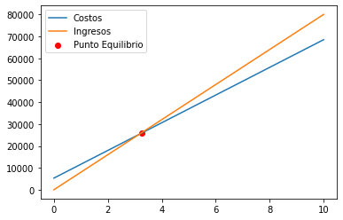

```python
import matplotlib.pyplot as plt
import numpy as np

MAX = 10

costosf = lambda n: CF+n*(VentaEjemplo.costo_total()+VentaEjemplo.𝜓)
ingresosf = lambda n: n*(VentaEjemplo.costo_total()+VentaEjemplo.𝜓+VentaEjemplo.beneficio)

X = np.linspace(0,MAX)
plt.plot(X, [costosf(i) for i in X], label="Costos")
plt.plot(X, [ingresosf(i) for i in X], label="Ingresos")

nv = 5320 / (0.28*(4300+1520))
plt.scatter(nv, costosf(nv), color="red", label="Punto Equilibrio")

plt.legend()
```